# StudentPerformance

```python
import numpy as np
import pandas as pd
import seaborn as sns
import matplotlib.pyplot as plt
%matplotlib inline
```

```python
performance = pd.read_csv('StudentPerformanceFactors.csv')
```

### Vizualizare Date

```python
performance
```

|  | Hours_Studied | Attendance | Parental_Involvement | Access_to_Resources | Extracurricular_Activities | Sleep_Hours | Previous_Scores | Motivation_Level | Internet_Access | Tutoring_Sessions | Family_Income | Teacher_Quality | School_Type | Peer_Influence | Physical_Activity | Learning_Disabilities | Parental_Education_Level | Distance_from_Home | Gender | Exam_Score |
| --- | --- | --- | --- | --- | --- | --- | --- | --- | --- | --- | --- | --- | --- | --- | --- | --- | --- | --- | --- | --- |
| 0 | 23 | 84 | Low | High | No | 7 | 73 | Low | Yes | 0 | Low | Medium | Public | Positive | 3 | No | High School | Near | Male | 67 |
| 1 | 19 | 64 | Low | Medium | No | 8 | 59 | Low | Yes | 2 | Medium | Medium | Public | Negative | 4 | No | College | Moderate | Female | 61 |
| 2 | 24 | 98 | Medium | Medium | Yes | 7 | 91 | Medium | Yes | 2 | Medium | Medium | Public | Neutral | 4 | No | Postgraduate | Near | Male | 74 |
| 3 | 29 | 89 | Low | Medium | Yes | 8 | 98 | Medium | Yes | 1 | Medium | Medium | Public | Negative | 4 | No | High School | Moderate | Male | 71 |
| 4 | 19 | 92 | Medium | Medium | Yes | 6 | 65 | Medium | Yes | 3 | Medium | High | Public | Neutral | 4 | No | College | Near | Female | 70 |
| ... | ... | ... | ... | ... | ... | ... | ... | ... | ... | ... | ... | ... | ... | ... | ... | ... | ... | ... | ... | ... |
| 6602 | 25 | 69 | High | Medium | No | 7 | 76 | Medium | Yes | 1 | High | Medium | Public | Positive | 2 | No | High School | Near | Female | 68 |
| 6603 | 23 | 76 | High | Medium | No | 8 | 81 | Medium | Yes | 3 | Low | High | Public | Positive | 2 | No | High School | Near | Female | 69 |
| 6604 | 20 | 90 | Medium | Low | Yes | 6 | 65 | Low | Yes | 3 | Low | Medium | Public | Negative | 2 | No | Postgraduate | Near | Female | 68 |
| 6605 | 10 | 86 | High | High | Yes | 6 | 91 | High | Yes | 2 | Low | Medium | Private | Positive | 3 | No | High School | Far | Female | 68 |
| 6606 | 15 | 67 | Medium | Low | Yes | 9 | 94 | Medium | Yes | 0 | Medium | Medium | Public | Positive | 4 | No | Postgraduate | Near | Male | 64 |

6607 rows × 20 columns

```python
performance.head()
```

|  | Hours_Studied | Attendance | Parental_Involvement | Access_to_Resources | Extracurricular_Activities | Sleep_Hours | Previous_Scores | Motivation_Level | Internet_Access | Tutoring_Sessions | Family_Income | Teacher_Quality | School_Type | Peer_Influence | Physical_Activity | Learning_Disabilities | Parental_Education_Level | Distance_from_Home | Gender | Exam_Score |
| --- | --- | --- | --- | --- | --- | --- | --- | --- | --- | --- | --- | --- | --- | --- | --- | --- | --- | --- | --- | --- |
| 0 | 23 | 84 | Low | High | No | 7 | 73 | Low | Yes | 0 | Low | Medium | Public | Positive | 3 | No | High School | Near | Male | 67 |
| 1 | 19 | 64 | Low | Medium | No | 8 | 59 | Low | Yes | 2 | Medium | Medium | Public | Negative | 4 | No | College | Moderate | Female | 61 |
| 2 | 24 | 98 | Medium | Medium | Yes | 7 | 91 | Medium | Yes | 2 | Medium | Medium | Public | Neutral | 4 | No | Postgraduate | Near | Male | 74 |
| 3 | 29 | 89 | Low | Medium | Yes | 8 | 98 | Medium | Yes | 1 | Medium | Medium | Public | Negative | 4 | No | High School | Moderate | Male | 71 |
| 4 | 19 | 92 | Medium | Medium | Yes | 6 | 65 | Medium | Yes | 3 | Medium | High | Public | Neutral | 4 | No | College | Near | Female | 70 |

### Verificam data type-ul valorilor

```python
performance.info()
```

```
<class 'pandas.DataFrame'>
RangeIndex: 6607 entries, 0 to 6606
Data columns (total 20 columns):
 #   Column                      Non-Null Count  Dtype
---  ------                      --------------  -----
 0   Hours_Studied               6607 non-null   int64
 1   Attendance                  6607 non-null   int64
 2   Parental_Involvement        6607 non-null   str
 3   Access_to_Resources         6607 non-null   str
 4   Extracurricular_Activities  6607 non-null   str
 5   Sleep_Hours                 6607 non-null   int64
 6   Previous_Scores             6607 non-null   int64
 7   Motivation_Level            6607 non-null   str
 8   Internet_Access             6607 non-null   str
 9   Tutoring_Sessions           6607 non-null   int64
 10  Family_Income               6607 non-null   str
 11  Teacher_Quality             6529 non-null   str
 12  School_Type                 6607 non-null   str
 13  Peer_Influence              6607 non-null   str
 14  Physical_Activity           6607 non-null   int64
 15  Learning_Disabilities       6607 non-null   str
 16  Parental_Education_Level    6517 non-null   str
 17  Distance_from_Home          6540 non-null   str
 18  Gender                      6607 non-null   str
 19  Exam_Score                  6607 non-null   int64
dtypes: int64(7), str(13)
memory usage: 1.0 MB
```

```python
performance.columns
```

```
Index(['Hours_Studied', 'Attendance', 'Parental_Involvement',
       'Access_to_Resources', 'Extracurricular_Activities', 'Sleep_Hours',
       'Previous_Scores', 'Motivation_Level', 'Internet_Access',
       'Tutoring_Sessions', 'Family_Income', 'Teacher_Quality', 'School_Type',
       'Peer_Influence', 'Physical_Activity', 'Learning_Disabilities',
       'Parental_Education_Level', 'Distance_from_Home', 'Gender',
       'Exam_Score'],
      dtype='str')
```

### Verificam intervalele sa vedem daca gasim outliers

```python
performance.describe()
```

|  | Hours_Studied | Attendance | Sleep_Hours | Previous_Scores | Tutoring_Sessions | Physical_Activity | Exam_Score |
| --- | --- | --- | --- | --- | --- | --- | --- |
| count | 6607.000000 | 6607.000000 | 6607.00000 | 6607.000000 | 6607.000000 | 6607.000000 | 6607.000000 |
| mean | 19.975329 | 79.977448 | 7.02906 | 75.070531 | 1.493719 | 2.967610 | 67.235659 |
| std | 5.990594 | 11.547475 | 1.46812 | 14.399784 | 1.230570 | 1.031231 | 3.890456 |
| min | 1.000000 | 60.000000 | 4.00000 | 50.000000 | 0.000000 | 0.000000 | 55.000000 |
| 25% | 16.000000 | 70.000000 | 6.00000 | 63.000000 | 1.000000 | 2.000000 | 65.000000 |
| 50% | 20.000000 | 80.000000 | 7.00000 | 75.000000 | 1.000000 | 3.000000 | 67.000000 |
| 75% | 24.000000 | 90.000000 | 8.00000 | 88.000000 | 2.000000 | 4.000000 | 69.000000 |
| max | 44.000000 | 100.000000 | 10.00000 | 100.000000 | 8.000000 | 6.000000 | 101.000000 |

```python
print("Exam_Score > 100:", (performance["Exam_Score"] > 100).sum())
```

```
Exam_Score > 100: 1
```

Observam ca maximul notei este 101, am verificat cate persoane au nota peste 100 sa vedem daca poate fi ceva general sau este un caz izolat/eroare de scriere cel mai probabil - am afisat linia studentului cu exam_score peste 100 pentru a verifica si celelalte statistici

```python
performance.loc[performance["Exam_Score"] > 100, :]
```

|  | Hours_Studied | Attendance | Parental_Involvement | Access_to_Resources | Extracurricular_Activities | Sleep_Hours | Previous_Scores | Motivation_Level | Internet_Access | Tutoring_Sessions | Family_Income | Teacher_Quality | School_Type | Peer_Influence | Physical_Activity | Learning_Disabilities | Parental_Education_Level | Distance_from_Home | Gender | Exam_Score |
| --- | --- | --- | --- | --- | --- | --- | --- | --- | --- | --- | --- | --- | --- | --- | --- | --- | --- | --- | --- | --- |
| 1525 | 27 | 98 | Low | Medium | Yes | 6 | 93 | Low | No | 5 | High | High | Public | Positive | 3 | No | High School | Moderate | Female | 101 |

Avand in vedere ca overall are attenadance foarte ridicat si scoruri ridicate la multe dintre coloane, si avand in vedere ca valoarea s-ar modifica cu 1% dintr-un total de 6606 de persoane, o sa aleg sa-i modificam exam_score la 100 astfel neafectand setul de date mai deloc si consideram cazul doar ca o eroare de scriere

```python
performance.loc[performance["Exam_Score"] == 101, "Exam_Score"] = 100
```

```python
print("Max Exam_Score:", performance["Exam_Score"].max())
```

```
Max Exam_Score: 100
```

Verificam ca s-a produs schimbarea in tabel - totul e verificat acum

```python
performance.isnull().sum()
```

```
Hours_Studied                  0
Attendance                     0
Parental_Involvement           0
Access_to_Resources            0
Extracurricular_Activities     0
Sleep_Hours                    0
Previous_Scores                0
Motivation_Level               0
Internet_Access                0
Tutoring_Sessions              0
Family_Income                  0
Teacher_Quality               78
School_Type                    0
Peer_Influence                 0
Physical_Activity              0
Learning_Disabilities          0
Parental_Education_Level      90
Distance_from_Home            67
Gender                         0
Exam_Score                     0
dtype: int64
```

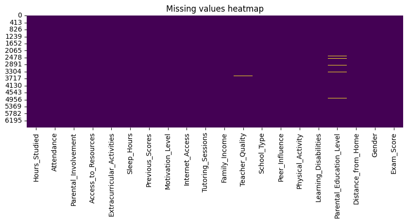

```python
plt.figure(figsize=(10, 3))
sns.heatmap(performance.isnull(), cbar=False, cmap="viridis")
plt.title("Missing values heatmap")
plt.show()
```

```python
cols_with_missing = ["Teacher_Quality", "Parental_Education_Level", "Distance_from_Home"]

for col in cols_with_missing:
    tmp = performance.groupby(performance[col].isna())["Exam_Score"].mean()
    print(f"\nMean Exam_Score by {col} missing:")
    display(tmp)
```

```
Mean Exam_Score by Teacher_Quality missing:
```

```
Teacher_Quality
False    67.242610
True     66.641026
Name: Exam_Score, dtype: float64
```

```
Mean Exam_Score by Parental_Education_Level missing:
```

```
Parental_Education_Level
False    67.237993
True     67.055556
Name: Exam_Score, dtype: float64
```

```
Mean Exam_Score by Distance_from_Home missing:
```

```
Distance_from_Home
False    67.243731
True     66.432836
Name: Exam_Score, dtype: float64
```

Putem observa ca media notelor de la examen intre cei cu acele valori lipsa si cei ce le au completate este ~ egala, diferenta fiind foarte minora ~ diff < 1%, astfel putem considera ca nota de la examen nu depinde in mod direct de lipsa datelor respective, astfel voi alege sa completez cazurile lipsa cu valoarea cea mai frecventa pe acele coloane

```python
cols_with_missing = ["Teacher_Quality", "Parental_Education_Level", "Distance_from_Home"]

for col in cols_with_missing:
    mode_val = performance[col].mode(dropna=True)[0]
    performance[col] = performance[col].fillna(mode_val)
```

```python
performance[cols_with_missing].isna().sum()
```

```
Teacher_Quality             0
Parental_Education_Level    0
Distance_from_Home          0
dtype: int64
```

```python
performance.duplicated().sum()
```

```
np.int64(0)
```

```python
performance.to_csv("performance_cleaned.csv", index=False)
```

```python
performance2 = pd.read_csv('performance_cleaned.csv')
```

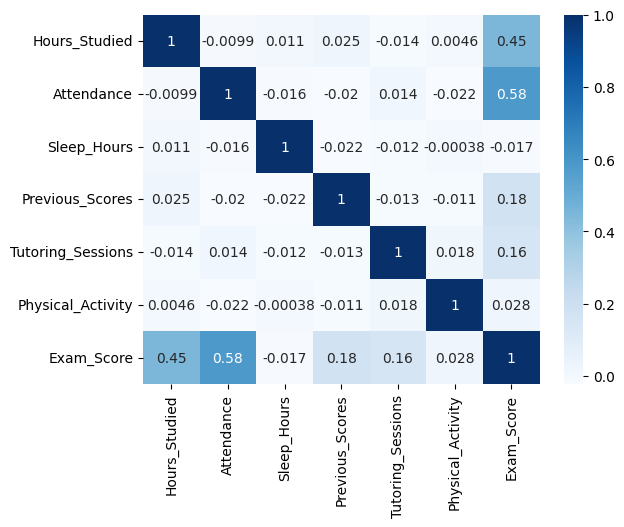

```python
corr_matrix_performance = performance2.corr(numeric_only=True)
sns.heatmap(corr_matrix_performance, annot=True, cmap='Blues')
```

Putem observa ca cea mai puternica corelatie cu Exam_score este cu numarul orelor studiate si cu prezenta, iar abia pe locul 3 si 4 notele anterioare si sesiunele de meditatii dar cu un scor semnificativ mai scazut decat primele 2

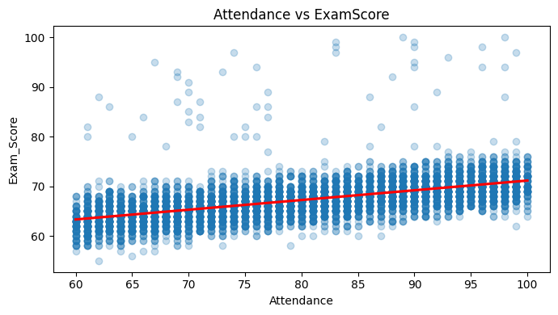

```python
plt.figure(figsize=(7, 4))
sns.regplot(data=performance2 , x="Attendance", y="Exam_Score", scatter_kws={"alpha": 0.25}, line_kws={"color": "red"})
plt.title("Attendance vs ExamScore")
plt.tight_layout()
plt.show()
```

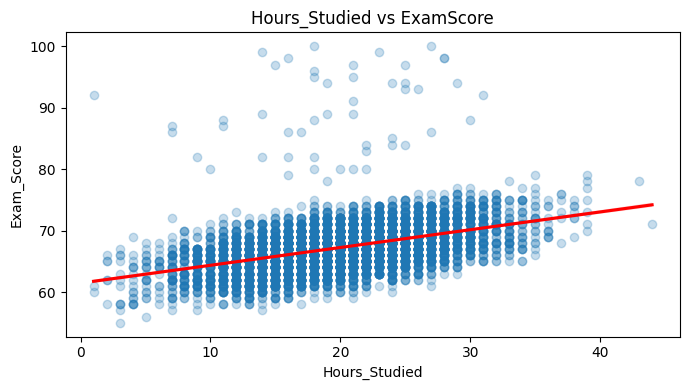

```python
plt.figure(figsize=(7, 4))
sns.regplot(data=performance2, x="Hours_Studied", y="Exam_Score", scatter_kws={"alpha": 0.25}, line_kws={"color": "red"})
plt.title("Hours_Studied vs ExamScore")
plt.tight_layout()
plt.show()
```

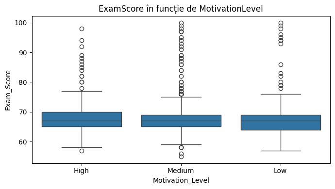

```python
plt.figure(figsize=(7, 4))
order = performance2.groupby("Motivation_Level")["Exam_Score"].mean().sort_values(ascending=False).index
sns.boxplot(data=performance2, x="Motivation_Level", y="Exam_Score", order=order)
plt.title("ExamScore în funcție de MotivationLevel")
plt.tight_layout()
plt.show()
```

Motivation_Level-ul nu pare sa fie un factor major pentru Exam_Score, putem gasi valori mari in toate grupele(note foarte bune) + Putem observa ca media notelor este foarte apropiata indiferent de nivelul de motivare

```python
lmh_map = {"Low": 0, "Medium": 1, "High": 2}

performance2["Parental_Involvement"]   = performance2["Parental_Involvement"].map(lmh_map)
performance2["Access_to_Resources"]    = performance2["Access_to_Resources"].map(lmh_map)
performance2["Motivation_Level"]       = performance2["Motivation_Level"].map(lmh_map)
performance2["Family_Income"]          = performance2["Family_Income"].map(lmh_map)
performance2["Teacher_Quality"]        = performance2["Teacher_Quality"].map(lmh_map)

yn_map = {"No": 0, "Yes": 1}
performance2["Extracurricular_Activities"] = performance2["Extracurricular_Activities"].map(yn_map)
performance2["Internet_Access"]            = performance2["Internet_Access"].map(yn_map)
performance2["Learning_Disabilities"]      = performance2["Learning_Disabilities"].map(yn_map)

school_map = {"Public": 0, "Private": 1}
performance2["School_Type"] = performance2["School_Type"].map(school_map)

gender_map = {"Male": 0, "Female": 1}
performance2["Gender"] = performance2["Gender"].map(gender_map)

peer_map = {"Negative": 0, "Neutral": 1, "Positive": 2}
performance2["Peer_Influence"] = performance2["Peer_Influence"].map(peer_map)

pedu_map = {"High School": 0, "College": 1, "Postgraduate": 2}
performance2["Parental_Education_Level"] = performance2["Parental_Education_Level"].map(pedu_map)

dist_map = {"Near": 0, "Moderate": 1, "Far": 2}
performance2["Distance_from_Home"] = performance2["Distance_from_Home"].map(dist_map)
```

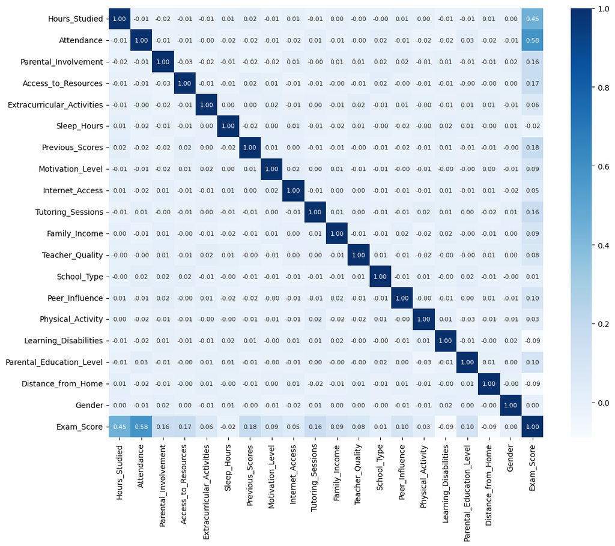

```python
plt.figure(figsize=(12, 10))  # sau (8, 6) pentru mai mult spațiu
corr_matrix_df = performance2.corr(numeric_only=True)

sns.heatmap(
    corr_matrix_df,
    annot=True,
    cmap='Blues',
    fmt=".2f",        # doar 2 zecimale
    annot_kws={"size": 8}  # font mai mic pentru numere
)

plt.tight_layout()
plt.show()
```

Am transformat toate valorile non-numerice in valori numerice si am afisat matricea completa de corelatie, am mai gasit niste corelatii interesante, dar nu destul de semnificative din punct de vedere al corelatiei directe cu Exam_Score de ex: Access_to_Resource, Parental_Involvement si Peer_Influence au o corelatie relativ mica dar importanta de semnalizat, iar pe de alta parte, Gender-ul nu conteaza deloc si School_Type-ul la fel

```python
performance2 = performance2.drop(columns=["Gender"], errors="ignore")
performance2.to_csv("performance_cleaned.csv", index=False)
```

```python
performance2.head()
```

|  | Hours_Studied | Attendance | Parental_Involvement | Access_to_Resources | Extracurricular_Activities | Sleep_Hours | Previous_Scores | Motivation_Level | Internet_Access | Tutoring_Sessions | Family_Income | Teacher_Quality | School_Type | Peer_Influence | Physical_Activity | Learning_Disabilities | Parental_Education_Level | Distance_from_Home | Exam_Score |
| --- | --- | --- | --- | --- | --- | --- | --- | --- | --- | --- | --- | --- | --- | --- | --- | --- | --- | --- | --- |
| 0 | 23 | 84 | 0 | 2 | 0 | 7 | 73 | 0 | 1 | 0 | 0 | 1 | 0 | 2 | 3 | 0 | 0 | 0 | 67 |
| 1 | 19 | 64 | 0 | 1 | 0 | 8 | 59 | 0 | 1 | 2 | 1 | 1 | 0 | 0 | 4 | 0 | 1 | 1 | 61 |
| 2 | 24 | 98 | 1 | 1 | 1 | 7 | 91 | 1 | 1 | 2 | 1 | 1 | 0 | 1 | 4 | 0 | 2 | 0 | 74 |
| 3 | 29 | 89 | 0 | 1 | 1 | 8 | 98 | 1 | 1 | 1 | 1 | 1 | 0 | 0 | 4 | 0 | 0 | 1 | 71 |
| 4 | 19 | 92 | 1 | 1 | 1 | 6 | 65 | 1 | 1 | 3 | 1 | 2 | 0 | 1 | 4 | 0 | 1 | 0 | 70 |

Stergem coloana gender pentru ca am observat ca nu este deloc relevanta pentru Exam_Score

# Impartim datele in seturi de antrenare, validare si testare

```python
from sklearn.model_selection import train_test_split
```

```python
df = pd.read_csv("performance_cleaned.csv")
```

```python
df.head()
```

|  | Hours_Studied | Attendance | Parental_Involvement | Access_to_Resources | Extracurricular_Activities | Sleep_Hours | Previous_Scores | Motivation_Level | Internet_Access | Tutoring_Sessions | Family_Income | Teacher_Quality | School_Type | Peer_Influence | Physical_Activity | Learning_Disabilities | Parental_Education_Level | Distance_from_Home | Exam_Score |
| --- | --- | --- | --- | --- | --- | --- | --- | --- | --- | --- | --- | --- | --- | --- | --- | --- | --- | --- | --- |
| 0 | 23 | 84 | 0 | 2 | 0 | 7 | 73 | 0 | 1 | 0 | 0 | 1 | 0 | 2 | 3 | 0 | 0 | 0 | 67 |
| 1 | 19 | 64 | 0 | 1 | 0 | 8 | 59 | 0 | 1 | 2 | 1 | 1 | 0 | 0 | 4 | 0 | 1 | 1 | 61 |
| 2 | 24 | 98 | 1 | 1 | 1 | 7 | 91 | 1 | 1 | 2 | 1 | 1 | 0 | 1 | 4 | 0 | 2 | 0 | 74 |
| 3 | 29 | 89 | 0 | 1 | 1 | 8 | 98 | 1 | 1 | 1 | 1 | 1 | 0 | 0 | 4 | 0 | 0 | 1 | 71 |
| 4 | 19 | 92 | 1 | 1 | 1 | 6 | 65 | 1 | 1 | 3 | 1 | 2 | 0 | 1 | 4 | 0 | 1 | 0 | 70 |

```python
features = df.drop("Exam_Score", axis=1)
labels = df["Exam_Score"]
```

```python
X_train, X_test, y_train, y_test = train_test_split(
    features,      # X
    labels,        # y
    test_size=0.4,
    random_state=42
)
```

```python
X_test, X_val, y_test, y_val = train_test_split(X_test, y_test, test_size=0.5, random_state=42)
```

```python
X_train
```

|  | Hours_Studied | Attendance | Parental_Involvement | Access_to_Resources | Extracurricular_Activities | Sleep_Hours | Previous_Scores | Motivation_Level | Internet_Access | Tutoring_Sessions | Family_Income | Teacher_Quality | School_Type | Peer_Influence | Physical_Activity | Learning_Disabilities | Parental_Education_Level | Distance_from_Home |
| --- | --- | --- | --- | --- | --- | --- | --- | --- | --- | --- | --- | --- | --- | --- | --- | --- | --- | --- |
| 6595 | 28 | 78 | 1 | 2 | 0 | 7 | 92 | 0 | 1 | 1 | 1 | 2 | 0 | 2 | 3 | 0 | 2 | 1 |
| 2176 | 10 | 94 | 2 | 1 | 1 | 7 | 74 | 2 | 1 | 3 | 2 | 1 | 0 | 2 | 3 | 0 | 1 | 1 |
| 3164 | 13 | 84 | 1 | 1 | 1 | 8 | 58 | 2 | 1 | 2 | 0 | 0 | 0 | 1 | 3 | 0 | 2 | 0 |
| 3650 | 22 | 85 | 0 | 2 | 1 | 8 | 73 | 2 | 1 | 1 | 1 | 1 | 1 | 2 | 3 | 0 | 1 | 0 |
| 5702 | 20 | 77 | 2 | 1 | 0 | 8 | 55 | 0 | 1 | 1 | 1 | 1 | 0 | 0 | 3 | 0 | 1 | 2 |
| ... | ... | ... | ... | ... | ... | ... | ... | ... | ... | ... | ... | ... | ... | ... | ... | ... | ... | ... |
| 3772 | 15 | 82 | 1 | 1 | 1 | 7 | 93 | 1 | 1 | 3 | 0 | 2 | 0 | 0 | 2 | 0 | 0 | 1 |
| 5191 | 20 | 65 | 1 | 1 | 1 | 8 | 97 | 2 | 1 | 0 | 0 | 1 | 0 | 0 | 3 | 0 | 1 | 0 |
| 5226 | 17 | 64 | 2 | 0 | 1 | 10 | 63 | 1 | 1 | 0 | 2 | 1 | 0 | 2 | 3 | 0 | 0 | 1 |
| 5390 | 16 | 100 | 2 | 2 | 1 | 7 | 82 | 1 | 1 | 2 | 2 | 1 | 0 | 2 | 2 | 0 | 0 | 0 |
| 860 | 21 | 62 | 1 | 0 | 0 | 6 | 74 | 2 | 1 | 0 | 0 | 2 | 1 | 2 | 3 | 1 | 2 | 2 |

3964 rows × 18 columns

```python
X_val
```

|  | Hours_Studied | Attendance | Parental_Involvement | Access_to_Resources | Extracurricular_Activities | Sleep_Hours | Previous_Scores | Motivation_Level | Internet_Access | Tutoring_Sessions | Family_Income | Teacher_Quality | School_Type | Peer_Influence | Physical_Activity | Learning_Disabilities | Parental_Education_Level | Distance_from_Home |
| --- | --- | --- | --- | --- | --- | --- | --- | --- | --- | --- | --- | --- | --- | --- | --- | --- | --- | --- |
| 3698 | 26 | 84 | 1 | 1 | 0 | 8 | 76 | 1 | 1 | 5 | 1 | 2 | 0 | 1 | 2 | 0 | 0 | 1 |
| 6589 | 22 | 90 | 0 | 2 | 0 | 5 | 99 | 1 | 1 | 1 | 0 | 0 | 1 | 2 | 2 | 0 | 1 | 0 |
| 6416 | 12 | 72 | 1 | 1 | 0 | 7 | 67 | 0 | 1 | 0 | 0 | 1 | 0 | 2 | 2 | 0 | 0 | 0 |
| 1533 | 19 | 85 | 2 | 1 | 1 | 9 | 71 | 0 | 1 | 1 | 1 | 2 | 0 | 2 | 2 | 0 | 2 | 1 |
| 420 | 32 | 68 | 1 | 0 | 0 | 8 | 97 | 2 | 1 | 1 | 0 | 1 | 0 | 2 | 2 | 0 | 0 | 0 |
| ... | ... | ... | ... | ... | ... | ... | ... | ... | ... | ... | ... | ... | ... | ... | ... | ... | ... | ... |
| 977 | 5 | 92 | 1 | 1 | 1 | 9 | 52 | 1 | 1 | 2 | 2 | 1 | 1 | 1 | 4 | 1 | 1 | 1 |
| 2351 | 24 | 91 | 1 | 0 | 1 | 9 | 76 | 2 | 1 | 1 | 0 | 0 | 0 | 2 | 4 | 0 | 1 | 0 |
| 4622 | 15 | 90 | 2 | 2 | 1 | 8 | 51 | 2 | 1 | 2 | 2 | 1 | 0 | 0 | 2 | 0 | 0 | 1 |
| 2559 | 26 | 100 | 0 | 1 | 0 | 9 | 60 | 1 | 1 | 2 | 1 | 1 | 0 | 2 | 4 | 0 | 0 | 0 |
| 5284 | 30 | 99 | 1 | 1 | 1 | 5 | 70 | 0 | 1 | 2 | 1 | 1 | 0 | 1 | 4 | 0 | 0 | 0 |

1322 rows × 18 columns

```python
X_test
```

|  | Hours_Studied | Attendance | Parental_Involvement | Access_to_Resources | Extracurricular_Activities | Sleep_Hours | Previous_Scores | Motivation_Level | Internet_Access | Tutoring_Sessions | Family_Income | Teacher_Quality | School_Type | Peer_Influence | Physical_Activity | Learning_Disabilities | Parental_Education_Level | Distance_from_Home |
| --- | --- | --- | --- | --- | --- | --- | --- | --- | --- | --- | --- | --- | --- | --- | --- | --- | --- | --- |
| 2251 | 29 | 96 | 0 | 0 | 0 | 4 | 89 | 1 | 1 | 2 | 0 | 2 | 0 | 1 | 2 | 0 | 0 | 2 |
| 2718 | 16 | 72 | 2 | 1 | 1 | 9 | 76 | 2 | 1 | 6 | 0 | 0 | 0 | 0 | 3 | 0 | 0 | 0 |
| 5784 | 19 | 97 | 2 | 1 | 0 | 5 | 78 | 0 | 1 | 2 | 0 | 1 | 0 | 2 | 3 | 0 | 0 | 0 |
| 2312 | 21 | 67 | 1 | 1 | 1 | 5 | 83 | 1 | 1 | 1 | 0 | 2 | 1 | 1 | 5 | 0 | 0 | 0 |
| 2228 | 9 | 65 | 1 | 1 | 0 | 4 | 88 | 0 | 1 | 1 | 0 | 1 | 0 | 2 | 3 | 0 | 1 | 0 |
| ... | ... | ... | ... | ... | ... | ... | ... | ... | ... | ... | ... | ... | ... | ... | ... | ... | ... | ... |
| 2227 | 16 | 95 | 0 | 1 | 1 | 5 | 65 | 2 | 1 | 0 | 1 | 1 | 1 | 1 | 3 | 0 | 1 | 0 |
| 1010 | 28 | 87 | 1 | 1 | 1 | 7 | 70 | 1 | 1 | 2 | 0 | 1 | 0 | 1 | 2 | 0 | 2 | 0 |
| 1433 | 17 | 68 | 1 | 2 | 1 | 8 | 71 | 1 | 1 | 1 | 1 | 2 | 1 | 1 | 2 | 0 | 0 | 0 |
| 418 | 27 | 62 | 1 | 2 | 1 | 5 | 63 | 0 | 1 | 4 | 2 | 1 | 0 | 0 | 4 | 0 | 0 | 0 |
| 3740 | 16 | 85 | 0 | 1 | 0 | 7 | 85 | 2 | 1 | 1 | 1 | 2 | 0 | 1 | 2 | 0 | 0 | 0 |

1321 rows × 18 columns

```python
y_train
```

```
6595    71
2176    70
3164    66
3650    70
5702    64
        ..
3772    66
5191    65
5226    62
5390    73
860     62
Name: Exam_Score, Length: 3964, dtype: int64
```

```python
y_val
```

```
3698    71
6589    70
6416    61
1533    69
420     68
        ..
977     64
2351    70
4622    68
2559    72
5284    74
Name: Exam_Score, Length: 1322, dtype: int64
```

```python
y_test
```

```
2251    70
2718    67
5784    71
2312    65
2228    61
        ..
2227    68
1010    71
1433    65
418     67
3740    66
Name: Exam_Score, Length: 1321, dtype: int64
```

```python
round(X_train.shape[0] / df.shape[0], 2)
```

```
0.6
```

```python
round(X_val.shape[0] / df.shape[0], 2)
```

```
0.2
```

```python
round(X_test.shape[0] / df.shape[0], 2)
```

```
0.2
```

## Salvam datele in fisiere CSV noi

```python
X_train.to_csv('train_features.csv', index=False)
X_val.to_csv('val_features.csv', index=False)
X_test.to_csv('test_features.csv', index=False)

y_train.to_csv('train_labels.csv', index=False)
y_val.to_csv('val_labels.csv', index=False)
y_test.to_csv('test_labels.csv', index=False)
```

```python
from sklearn.ensemble import RandomForestRegressor    # modelul ML pe care-l vom folosi
from sklearn.model_selection import cross_val_score    # avem nevoie pentru evaluarea cross-validation
```

```python
train_features = pd.read_csv('train_features.csv')
train_labels = pd.read_csv('train_labels.csv')
```

```python
rf_model = RandomForestRegressor()

rf_model_scores = cross_val_score(
    rf_model,
    features,
    labels.values.ravel(),
    cv=5,
    scoring="neg_mean_absolute_error"
)
```

```python
rf_model_scores
```

```
array([-1.14234493, -1.13985628, -1.1193944 , -1.06651022, -1.03400454])
```

Modelul greseste cu circa un punct la nota examenului

```python
from sklearn.model_selection import GridSearchCV
```

```python
rf_model = RandomForestRegressor()

h_params = {
    "n_estimators": [50, 100, 200],
    "max_depth": [5, 10, 20, None]
}

cv_rf_model = GridSearchCV(
    rf_model,
    h_params,
    cv=5,
    scoring="neg_mean_absolute_error"
)

cv_rf_model.fit(features, labels.values.ravel())
```

```
GridSearchCV(cv=5, estimator=RandomForestRegressor(),
             param_grid={'max_depth': [5, 10, 20, None],
                         'n_estimators': [50, 100, 200]},
             scoring='neg_mean_absolute_error')
```

```python
cv_rf_model.best_params_
```

```
{'max_depth': 20, 'n_estimators': 200}
```

```python
cv_rf_model.cv_results_
```

```
{'mean_fit_time': array([0.37716594, 0.67751527, 1.38833084, 0.80334802, 1.3783154 ,
        2.74339128, 1.1033514 , 2.02502108, 4.03662162, 1.08800058,
        2.13642106, 5.3240243 ]),
 'std_fit_time': array([0.03162022, 0.04615833, 0.28017428, 0.12365157, 0.12885368,
        0.22278907, 0.1841898 , 0.07647225, 0.14509389, 0.11311582,
        0.17690983, 0.53663053]),
 'mean_score_time': array([0.01111455, 0.02082686, 0.03809233, 0.01361351, 0.02795839,
        0.04694343, 0.01544361, 0.03525667, 0.06690969, 0.01586814,
        0.02988229, 0.08293366]),
 'std_score_time': array([0.0016574 , 0.00499797, 0.00963432, 0.00336486, 0.00482201,
        0.00974131, 0.00143033, 0.00282835, 0.00788278, 0.00213344,
        0.00235469, 0.01628279]),
 'param_max_depth': masked_array(data=[5, 5, 5, 10, 10, 10, 20, 20, 20, None, None, None],
              mask=[False, False, False, False, False, False, False, False,
                    False, False, False, False],
        fill_value=np.str_('?'),
             dtype=object),
 'param_n_estimators': masked_array(data=[50, 100, 200, 50, 100, 200, 50, 100, 200, 50, 100, 200],
              mask=[False, False, False, False, False, False, False, False,
                    False, False, False, False],
        fill_value=999999),
 'params': [{'max_depth': 5, 'n_estimators': 50},
  {'max_depth': 5, 'n_estimators': 100},
  {'max_depth': 5, 'n_estimators': 200},
  {'max_depth': 10, 'n_estimators': 50},
  {'max_depth': 10, 'n_estimators': 100},
  {'max_depth': 10, 'n_estimators': 200},
  {'max_depth': 20, 'n_estimators': 50},
  {'max_depth': 20, 'n_estimators': 100},
  {'max_depth': 20, 'n_estimators': 200},
  {'max_depth': None, 'n_estimators': 50},
  {'max_depth': None, 'n_estimators': 100},
  {'max_depth': None, 'n_estimators': 200}],
 'split0_test_score': array([-1.52714861, -1.52349039, -1.52106046, -1.24291229, -1.2252175 ,
        -1.2079037 , -1.15480608, -1.14737775, -1.13706696, -1.15944024,
        -1.14670953, -1.14162632]),
 'split1_test_score': array([-1.5330554 , -1.52925406, -1.52303078, -1.23121045, -1.22009265,
        -1.22448983, -1.18323025, -1.16389373, -1.14147522, -1.17118003,
        -1.13608926, -1.13907716]),
 'split2_test_score': array([-1.4985213 , -1.49564952, -1.49811225, -1.21858907, -1.19507973,
        -1.19187183, -1.14569917, -1.10596769, -1.10472757, -1.1333081 ,
        -1.12527631, -1.11242998]),
 'split3_test_score': array([-1.45968173, -1.4605809 , -1.45538533, -1.1636376 , -1.15859318,
        -1.15082631, -1.11054017, -1.08274059, -1.07253945, -1.10274035,
        -1.08408781, -1.07725965]),
 'split4_test_score': array([-1.41813296, -1.41221773, -1.40692519, -1.14097395, -1.12965306,
        -1.11371953, -1.07866516, -1.04538233, -1.01439942, -1.05566995,
        -1.04538229, -1.02506435]),
 'mean_test_score': array([-1.487308  , -1.48423852, -1.4809028 , -1.19946467, -1.18572722,
        -1.17776224, -1.13458816, -1.10907242, -1.09404172, -1.12446773,
        -1.10750904, -1.09909149]),
 'std_test_score': array([0.04325329, 0.04346032, 0.04428859, 0.03991485, 0.03662923,
        0.04029409, 0.0363427 , 0.04297001, 0.04694793, 0.04168569,
        0.03762305, 0.04368668]),
 'rank_test_score': array([12, 11, 10,  9,  8,  7,  6,  4,  1,  5,  3,  2], dtype=int32)}
```

```python
from sklearn.metrics import mean_absolute_error, mean_squared_error, r2_score
```

```python
train_features = pd.read_csv('train_features.csv')
train_labels = pd.read_csv('train_labels.csv')

val_features = pd.read_csv('val_features.csv')
val_labels = pd.read_csv('val_labels.csv')

test_features = pd.read_csv('test_features.csv')
test_labels = pd.read_csv('test_labels.csv')
```

```python
rf_model_1 = RandomForestRegressor(n_estimators=200, max_depth=None, random_state=42)
rf_model_1.fit(train_features, train_labels.values.ravel())
```

```
RandomForestRegressor(n_estimators=200, random_state=42)
```

```python
rf_model_2 = RandomForestRegressor(n_estimators=200, max_depth=20, random_state=42)
rf_model_2.fit(train_features, train_labels.values.ravel())
```

```
RandomForestRegressor(max_depth=20, n_estimators=200, random_state=42)
```

```python
rf_model_3 = RandomForestRegressor(n_estimators=100, max_depth=None, random_state=42)
rf_model_3.fit(train_features, train_labels.values.ravel())
```

```
RandomForestRegressor(random_state=42)
```

```python
y_predict_rf1 = rf_model_1.predict(val_features)
y_predict_rf1
```

```
array([69.79 , 71.865, 61.675, ..., 69.97 , 71.315, 72.69 ], shape=(1322,))
```

```python
y_predict_rf2 = rf_model_2.predict(val_features)
y_predict_rf2
```

```
array([69.765, 71.735, 61.685, ..., 69.82 , 71.305, 72.685], shape=(1322,))
```

```python
y_predict_rf3 = rf_model_3.predict(val_features)
y_predict_rf3
```

```
array([69.92, 71.93, 61.45, ..., 70.99, 71.36, 72.65], shape=(1322,))
```

```python
from sklearn.metrics import mean_absolute_error, mean_squared_error, r2_score
import numpy as np

for model in [rf_model_1, rf_model_2, rf_model_3]:
    y_pred = model.predict(val_features)

    mae  = round(mean_absolute_error(val_labels, y_pred), 3)
    mse  = mean_squared_error(val_labels, y_pred)      # doar MSE
    rmse = round(np.sqrt(mse), 3)                      # radical din MSE
    r2   = round(r2_score(val_labels, y_pred), 3)

    print(
        f'max_depth: {model.max_depth}, n_estimators: {model.n_estimators} '
        f'__ MAE: {mae} / RMSE: {rmse} / R2: {r2}'
    )
```

```
max_depth: None, n_estimators: 200 __ MAE: 1.131 / RMSE: 2.27 / R2: 0.641
max_depth: 20, n_estimators: 200 __ MAE: 1.131 / RMSE: 2.268 / R2: 0.642
max_depth: None, n_estimators: 100 __ MAE: 1.142 / RMSE: 2.289 / R2: 0.635
```

```python
best_model = cv_rf_model.best_estimator_
```

```python
print(cv_rf_model.best_params_)
```

```
{'max_depth': 20, 'n_estimators': 200}
```

```python
y_pred_test = best_model.predict(test_features)

mae  = round(mean_absolute_error(test_labels, y_pred_test), 3)
mse  = mean_squared_error(test_labels, y_pred_test)
rmse = round(np.sqrt(mse), 3)
r2   = round(r2_score(test_labels, y_pred_test), 3)

print(
    f'Model final (GridSearchCV) --> \n\n'
    f' max_depth: {best_model.max_depth}, \n'
    f' n_estimators: {best_model.n_estimators}, \n\n'
    f' MAE: {mae} \n'
    f' RMSE: {rmse} \n'
    f' R2: {r2}'
)
```

```
Model final (GridSearchCV) -->

 max_depth: 20,
 n_estimators: 200,

 MAE: 0.375
 RMSE: 0.749
 R2: 0.959
```

```python
df = pd.read_csv("performance_cleaned.csv")
```

```python
df.head()
```

|  | Hours_Studied | Attendance | Parental_Involvement | Access_to_Resources | Extracurricular_Activities | Sleep_Hours | Previous_Scores | Motivation_Level | Internet_Access | Tutoring_Sessions | Family_Income | Teacher_Quality | School_Type | Peer_Influence | Physical_Activity | Learning_Disabilities | Parental_Education_Level | Distance_from_Home | Exam_Score |
| --- | --- | --- | --- | --- | --- | --- | --- | --- | --- | --- | --- | --- | --- | --- | --- | --- | --- | --- | --- |
| 0 | 23 | 84 | 0 | 2 | 0 | 7 | 73 | 0 | 1 | 0 | 0 | 1 | 0 | 2 | 3 | 0 | 0 | 0 | 67 |
| 1 | 19 | 64 | 0 | 1 | 0 | 8 | 59 | 0 | 1 | 2 | 1 | 1 | 0 | 0 | 4 | 0 | 1 | 1 | 61 |
| 2 | 24 | 98 | 1 | 1 | 1 | 7 | 91 | 1 | 1 | 2 | 1 | 1 | 0 | 1 | 4 | 0 | 2 | 0 | 74 |
| 3 | 29 | 89 | 0 | 1 | 1 | 8 | 98 | 1 | 1 | 1 | 1 | 1 | 0 | 0 | 4 | 0 | 0 | 1 | 71 |
| 4 | 19 | 92 | 1 | 1 | 1 | 6 | 65 | 1 | 1 | 3 | 1 | 2 | 0 | 1 | 4 | 0 | 1 | 0 | 70 |

```python
features = df.drop('Exam_Score', axis=1)
labels = df['Exam_Score']
```

```python
best_model = cv_rf_model.best_estimator_

best_model.fit(features, labels)

y_pred_all = best_model.predict(features)

mae_all  = round(mean_absolute_error(labels, y_pred_all), 3)
mse_all  = mean_squared_error(labels, y_pred_all)
rmse_all = round(np.sqrt(mse_all), 3)
r2_all   = round(r2_score(labels, y_pred_all), 3)

print(
    f'Model (pe tot setul) --> \n\n'
    f' max_depth: {best_model.max_depth}, \n'
    f' n_estimators: {best_model.n_estimators}, \n\n'
    f' MAE: {mae_all} \n'
    f' RMSE: {rmse_all} \n'
    f' R2: {r2_all}'
)
```

```
Model (pe tot setul) -->

 max_depth: 20,
 n_estimators: 200,

 MAE: 0.407
 RMSE: 0.854
 R2: 0.952
```

```python
features
```

|  | Hours_Studied | Attendance | Parental_Involvement | Access_to_Resources | Extracurricular_Activities | Sleep_Hours | Previous_Scores | Motivation_Level | Internet_Access | Tutoring_Sessions | Family_Income | Teacher_Quality | School_Type | Peer_Influence | Physical_Activity | Learning_Disabilities | Parental_Education_Level | Distance_from_Home |
| --- | --- | --- | --- | --- | --- | --- | --- | --- | --- | --- | --- | --- | --- | --- | --- | --- | --- | --- |
| 0 | 23 | 84 | 0 | 2 | 0 | 7 | 73 | 0 | 1 | 0 | 0 | 1 | 0 | 2 | 3 | 0 | 0 | 0 |
| 1 | 19 | 64 | 0 | 1 | 0 | 8 | 59 | 0 | 1 | 2 | 1 | 1 | 0 | 0 | 4 | 0 | 1 | 1 |
| 2 | 24 | 98 | 1 | 1 | 1 | 7 | 91 | 1 | 1 | 2 | 1 | 1 | 0 | 1 | 4 | 0 | 2 | 0 |
| 3 | 29 | 89 | 0 | 1 | 1 | 8 | 98 | 1 | 1 | 1 | 1 | 1 | 0 | 0 | 4 | 0 | 0 | 1 |
| 4 | 19 | 92 | 1 | 1 | 1 | 6 | 65 | 1 | 1 | 3 | 1 | 2 | 0 | 1 | 4 | 0 | 1 | 0 |
| ... | ... | ... | ... | ... | ... | ... | ... | ... | ... | ... | ... | ... | ... | ... | ... | ... | ... | ... |
| 6602 | 25 | 69 | 2 | 1 | 0 | 7 | 76 | 1 | 1 | 1 | 2 | 1 | 0 | 2 | 2 | 0 | 0 | 0 |
| 6603 | 23 | 76 | 2 | 1 | 0 | 8 | 81 | 1 | 1 | 3 | 0 | 2 | 0 | 2 | 2 | 0 | 0 | 0 |
| 6604 | 20 | 90 | 1 | 0 | 1 | 6 | 65 | 0 | 1 | 3 | 0 | 1 | 0 | 0 | 2 | 0 | 2 | 0 |
| 6605 | 10 | 86 | 2 | 2 | 1 | 6 | 91 | 2 | 1 | 2 | 0 | 1 | 1 | 2 | 3 | 0 | 0 | 2 |
| 6606 | 15 | 67 | 1 | 0 | 1 | 9 | 94 | 1 | 1 | 0 | 1 | 1 | 0 | 2 | 4 | 0 | 2 | 0 |

6607 rows × 18 columns

```python
labels
```

```
0       67
1       61
2       74
3       71
4       70
        ..
6602    68
6603    69
6604    68
6605    68
6606    64
Name: Exam_Score, Length: 6607, dtype: int64
```

```python
y_pred_all
```

```
array([67.695, 61.225, 74.43 , ..., 68.08 , 67.675, 63.64 ], shape=(6607,))
```

```python
df['Model Prediction'] = y_pred_all
```

```python
df
```

|  | Hours_Studied | Attendance | Parental_Involvement | Access_to_Resources | Extracurricular_Activities | Sleep_Hours | Previous_Scores | Motivation_Level | Internet_Access | Tutoring_Sessions | Family_Income | Teacher_Quality | School_Type | Peer_Influence | Physical_Activity | Learning_Disabilities | Parental_Education_Level | Distance_from_Home | Exam_Score | Model Prediction |
| --- | --- | --- | --- | --- | --- | --- | --- | --- | --- | --- | --- | --- | --- | --- | --- | --- | --- | --- | --- | --- |
| 0 | 23 | 84 | 0 | 2 | 0 | 7 | 73 | 0 | 1 | 0 | 0 | 1 | 0 | 2 | 3 | 0 | 0 | 0 | 67 | 67.695 |
| 1 | 19 | 64 | 0 | 1 | 0 | 8 | 59 | 0 | 1 | 2 | 1 | 1 | 0 | 0 | 4 | 0 | 1 | 1 | 61 | 61.225 |
| 2 | 24 | 98 | 1 | 1 | 1 | 7 | 91 | 1 | 1 | 2 | 1 | 1 | 0 | 1 | 4 | 0 | 2 | 0 | 74 | 74.430 |
| 3 | 29 | 89 | 0 | 1 | 1 | 8 | 98 | 1 | 1 | 1 | 1 | 1 | 0 | 0 | 4 | 0 | 0 | 1 | 71 | 71.395 |
| 4 | 19 | 92 | 1 | 1 | 1 | 6 | 65 | 1 | 1 | 3 | 1 | 2 | 0 | 1 | 4 | 0 | 1 | 0 | 70 | 69.980 |
| ... | ... | ... | ... | ... | ... | ... | ... | ... | ... | ... | ... | ... | ... | ... | ... | ... | ... | ... | ... | ... |
| 6602 | 25 | 69 | 2 | 1 | 0 | 7 | 76 | 1 | 1 | 1 | 2 | 1 | 0 | 2 | 2 | 0 | 0 | 0 | 68 | 67.485 |
| 6603 | 23 | 76 | 2 | 1 | 0 | 8 | 81 | 1 | 1 | 3 | 0 | 2 | 0 | 2 | 2 | 0 | 0 | 0 | 69 | 69.025 |
| 6604 | 20 | 90 | 1 | 0 | 1 | 6 | 65 | 0 | 1 | 3 | 0 | 1 | 0 | 0 | 2 | 0 | 2 | 0 | 68 | 68.080 |
| 6605 | 10 | 86 | 2 | 2 | 1 | 6 | 91 | 2 | 1 | 2 | 0 | 1 | 1 | 2 | 3 | 0 | 0 | 2 | 68 | 67.675 |
| 6606 | 15 | 67 | 1 | 0 | 1 | 9 | 94 | 1 | 1 | 0 | 1 | 1 | 0 | 2 | 4 | 0 | 2 | 0 | 64 | 63.640 |

6607 rows × 20 columns

```python
df_all = pd.read_csv("StudentPerformanceFactors.csv")
```

```python
df_all['Model Prediction'] = y_pred_all
```

```python
df_all["AbsError"] = (df_all["Exam_Score"] - df_all["Model Prediction"]).abs()
```

```python
df_all["AbsError"].describe()
```

```
count    6607.000000
mean        0.407029
std         0.752839
min         0.000000
25%         0.130000
50%         0.280000
75%         0.485000
max        12.135000
Name: AbsError, dtype: float64
```

```python
df_all[df_all["AbsError"] > 1]
```

|  | Hours_Studied | Attendance | Parental_Involvement | Access_to_Resources | Extracurricular_Activities | Sleep_Hours | Previous_Scores | Motivation_Level | Internet_Access | Tutoring_Sessions | ... | School_Type | Peer_Influence | Physical_Activity | Learning_Disabilities | Parental_Education_Level | Distance_from_Home | Gender | Exam_Score | Model Prediction | AbsError |
| --- | --- | --- | --- | --- | --- | --- | --- | --- | --- | --- | --- | --- | --- | --- | --- | --- | --- | --- | --- | --- | --- |
| 75 | 25 | 70 | Medium | Medium | No | 7 | 52 | Medium | Yes | 1 | ... | Public | Positive | 3 | No | Postgraduate | Near | Female | 66 | 67.120 | 1.120 |
| 94 | 18 | 89 | High | Medium | Yes | 4 | 73 | Medium | Yes | 3 | ... | Private | Positive | 2 | No | College | Near | Female | 100 | 87.865 | 12.135 |
| 113 | 35 | 99 | High | High | Yes | 7 | 85 | Low | Yes | 2 | ... | Private | Neutral | 2 | No | Postgraduate | Near | Female | 79 | 77.610 | 1.390 |
| 195 | 22 | 79 | High | Medium | No | 5 | 100 | Medium | Yes | 4 | ... | Public | Negative | 3 | No | College | Near | Male | 72 | 70.790 | 1.210 |
| 209 | 43 | 86 | High | Medium | Yes | 7 | 97 | Medium | Yes | 2 | ... | Public | Positive | 1 | No | High School | Near | Female | 78 | 76.305 | 1.695 |
| ... | ... | ... | ... | ... | ... | ... | ... | ... | ... | ... | ... | ... | ... | ... | ... | ... | ... | ... | ... | ... | ... |
| 6522 | 18 | 90 | High | High | Yes | 6 | 54 | Low | Yes | 1 | ... | Public | Negative | 3 | No | High School | Near | Female | 95 | 86.240 | 8.760 |
| 6532 | 29 | 97 | Medium | High | Yes | 9 | 92 | Medium | Yes | 2 | ... | Public | Positive | 4 | No | High School | Moderate | Female | 75 | 76.300 | 1.300 |
| 6592 | 29 | 100 | Medium | Low | Yes | 8 | 100 | Low | Yes | 0 | ... | Private | Neutral | 5 | Yes | High School | Near | Male | 72 | 73.035 | 1.035 |
| 6594 | 9 | 90 | High | High | Yes | 7 | 79 | Low | Yes | 4 | ... | Public | Positive | 4 | No | High School | NaN | Male | 70 | 71.040 | 1.040 |
| 6599 | 30 | 94 | Medium | Low | No | 5 | 52 | Low | No | 3 | ... | Private | Neutral | 2 | No | Postgraduate | Moderate | Female | 70 | 71.075 | 1.075 |

274 rows × 22 columns

```python
df_all[df_all["AbsError"] > 3]
```

|  | Hours_Studied | Attendance | Parental_Involvement | Access_to_Resources | Extracurricular_Activities | Sleep_Hours | Previous_Scores | Motivation_Level | Internet_Access | Tutoring_Sessions | ... | School_Type | Peer_Influence | Physical_Activity | Learning_Disabilities | Parental_Education_Level | Distance_from_Home | Gender | Exam_Score | Model Prediction | AbsError |
| --- | --- | --- | --- | --- | --- | --- | --- | --- | --- | --- | --- | --- | --- | --- | --- | --- | --- | --- | --- | --- | --- |
| 94 | 18 | 89 | High | Medium | Yes | 4 | 73 | Medium | Yes | 3 | ... | Private | Positive | 2 | No | College | Near | Female | 100 | 87.865 | 12.135 |
| 217 | 19 | 70 | Medium | Low | No | 7 | 54 | High | Yes | 0 | ... | Public | Positive | 2 | Yes | High School | Moderate | Male | 89 | 78.460 | 10.540 |
| 404 | 17 | 77 | Low | High | Yes | 5 | 53 | Medium | Yes | 2 | ... | Public | Neutral | 3 | No | College | Near | Male | 86 | 79.220 | 6.780 |
| 529 | 15 | 83 | Medium | Medium | No | 7 | 97 | Medium | Yes | 2 | ... | Private | Neutral | 2 | No | High School | Near | Female | 97 | 87.025 | 9.975 |
| 558 | 22 | 70 | Low | Medium | No | 7 | 53 | Low | Yes | 1 | ... | Public | Positive | 3 | No | High School | Near | Female | 83 | 76.635 | 6.365 |
| 560 | 22 | 71 | Low | High | Yes | 9 | 56 | High | Yes | 1 | ... | Public | Neutral | 3 | Yes | College | Near | Female | 84 | 76.920 | 7.080 |
| 637 | 20 | 65 | Medium | Low | Yes | 7 | 62 | High | Yes | 0 | ... | Public | Neutral | 0 | Yes | Postgraduate | Near | Male | 80 | 73.620 | 6.380 |
| 770 | 24 | 96 | Low | High | No | 6 | 93 | Medium | Yes | 2 | ... | Public | Neutral | 2 | No | High School | Moderate | Female | 94 | 86.515 | 7.485 |
| 836 | 29 | 76 | Medium | Medium | No | 8 | 96 | Low | Yes | 2 | ... | Public | Positive | 2 | No | Postgraduate | Moderate | Male | 94 | 84.920 | 9.080 |
| 919 | 21 | 74 | High | Medium | No | 6 | 94 | Medium | Yes | 1 | ... | Public | Positive | 1 | No | High School | Near | Male | 97 | 88.165 | 8.835 |
| 1099 | 22 | 75 | Medium | Low | Yes | 5 | 66 | Low | Yes | 2 | ... | Public | Positive | 2 | No | High School | Far | Male | 80 | 75.135 | 4.865 |
| 1107 | 14 | 77 | Low | High | No | 6 | 75 | Medium | Yes | 1 | ... | Public | Neutral | 4 | Yes | High School | Near | Female | 89 | 78.940 | 10.060 |
| 1109 | 31 | 69 | Medium | Medium | No | 7 | 52 | Medium | No | 2 | ... | Public | Neutral | 5 | No | College | Far | Male | 92 | 83.625 | 8.375 |
| 1351 | 9 | 61 | High | Medium | Yes | 6 | 77 | Low | No | 1 | ... | Private | Neutral | 2 | No | High School | Near | Male | 82 | 75.940 | 6.060 |
| 1525 | 27 | 98 | Low | Medium | Yes | 6 | 93 | Low | No | 5 | ... | Public | Positive | 3 | No | High School | Moderate | Female | 101 | 91.290 | 9.710 |
| 1607 | 30 | 98 | Medium | Low | Yes | 9 | 93 | Medium | Yes | 1 | ... | Private | Positive | 3 | No | High School | Near | Male | 88 | 83.025 | 4.975 |
| 1844 | 21 | 92 | High | High | Yes | 9 | 58 | Medium | Yes | 2 | ... | Public | Neutral | 5 | No | High School | Moderate | Female | 89 | 81.740 | 7.260 |
| 1863 | 10 | 76 | Medium | Low | No | 6 | 76 | Medium | Yes | 1 | ... | Public | Negative | 2 | No | Postgraduate | Near | Male | 80 | 73.560 | 6.440 |
| 2076 | 24 | 77 | High | Medium | Yes | 7 | 57 | Medium | Yes | 3 | ... | Public | Positive | 2 | No | College | Far | Male | 84 | 78.225 | 5.775 |
| 2292 | 21 | 70 | High | High | No | 9 | 66 | Medium | Yes | 1 | ... | Public | Neutral | 4 | No | College | Moderate | Male | 91 | 81.515 | 9.485 |
| 2421 | 27 | 90 | Low | Medium | No | 9 | 52 | Low | No | 2 | ... | Public | Positive | 2 | Yes | College | Near | Male | 86 | 81.390 | 4.610 |
| 2425 | 23 | 83 | High | High | Yes | 4 | 89 | Low | Yes | 1 | ... | Public | Negative | 3 | No | High School | Far | Male | 99 | 88.125 | 10.875 |
| 2513 | 18 | 86 | High | Medium | No | 8 | 60 | Medium | Yes | 2 | ... | Private | Neutral | 1 | No | College | Near | Male | 88 | 81.010 | 6.990 |
| 2542 | 19 | 68 | Medium | Medium | Yes | 5 | 80 | Medium | Yes | 0 | ... | Public | Neutral | 3 | Yes | High School | Moderate | Male | 78 | 72.955 | 5.045 |
| 2595 | 7 | 69 | Medium | High | Yes | 8 | 54 | High | Yes | 1 | ... | Public | Positive | 2 | No | High School | Far | Male | 87 | 77.040 | 9.960 |
| 2650 | 15 | 83 | Medium | High | No | 4 | 98 | Low | Yes | 3 | ... | Public | Positive | 3 | No | High School | Moderate | Female | 68 | 71.890 | 3.890 |
| 2687 | 11 | 71 | Low | Medium | Yes | 8 | 55 | Medium | Yes | 1 | ... | Public | Negative | 3 | No | College | Near | Female | 87 | 78.860 | 8.140 |
| 2904 | 11 | 62 | High | Medium | Yes | 7 | 76 | High | Yes | 3 | ... | Private | Neutral | 3 | Yes | High School | Moderate | Male | 88 | 79.100 | 8.900 |
| 2954 | 14 | 75 | Medium | Medium | Yes | 5 | 95 | Medium | Yes | 0 | ... | Public | Positive | 3 | No | College | Moderate | Male | 82 | 75.695 | 6.305 |
| 3124 | 19 | 90 | Medium | High | Yes | 5 | 90 | Low | Yes | 0 | ... | Public | Neutral | 2 | No | College | Far | Female | 94 | 85.340 | 8.660 |
| 3141 | 7 | 63 | High | High | Yes | 10 | 90 | Medium | Yes | 0 | ... | Private | Positive | 2 | Yes | High School | Moderate | Male | 86 | 76.005 | 9.995 |
| 3364 | 16 | 76 | Medium | High | Yes | 6 | 63 | High | Yes | 0 | ... | Public | Positive | 1 | No | High School | Near | Female | 86 | 77.450 | 8.550 |
| 3457 | 18 | 93 | Medium | Medium | No | 7 | 76 | Low | Yes | 2 | ... | Private | Neutral | 4 | No | High School | Near | Female | 96 | 85.760 | 10.240 |
| 3579 | 14 | 90 | High | High | Yes | 8 | 86 | Medium | Yes | 4 | ... | Private | Negative | 2 | No | High School | Near | Female | 99 | 88.445 | 10.555 |
| 3924 | 18 | 87 | Low | Low | No | 8 | 79 | High | Yes | 1 | ... | Public | Negative | 4 | No | College | Near | Male | 82 | 75.935 | 6.065 |
| 3932 | 25 | 66 | High | Medium | Yes | 7 | 55 | Medium | Yes | 4 | ... | Public | Neutral | 2 | Yes | High School | Moderate | Female | 84 | 76.155 | 7.845 |
| 4192 | 28 | 90 | Low | Medium | Yes | 9 | 91 | Medium | Yes | 0 | ... | Public | Positive | 2 | No | College | Moderate | Female | 98 | 87.745 | 10.255 |
| 4254 | 21 | 74 | High | Low | Yes | 8 | 64 | Medium | Yes | 3 | ... | Public | Neutral | 1 | No | College | Far | Male | 80 | 74.890 | 5.110 |
| 4297 | 21 | 67 | Medium | Medium | Yes | 6 | 88 | Medium | Yes | 1 | ... | Private | Positive | 5 | No | Postgraduate | Near | Female | 95 | 85.375 | 9.625 |
| 4355 | 24 | 70 | Medium | High | Yes | 9 | 52 | High | Yes | 1 | ... | Public | Positive | 2 | No | Postgraduate | Moderate | Male | 85 | 79.125 | 5.875 |
| 4405 | 25 | 98 | Medium | Medium | Yes | 7 | 90 | High | Yes | 1 | ... | Public | Neutral | 4 | No | Postgraduate | Near | Male | 94 | 86.520 | 7.480 |
| 4531 | 26 | 69 | High | High | No | 7 | 95 | Low | No | 0 | ... | Public | Negative | 3 | No | Postgraduate | Near | Female | 93 | 84.245 | 8.755 |
| 4583 | 25 | 73 | Medium | Medium | Yes | 7 | 56 | Medium | Yes | 2 | ... | Public | Neutral | 4 | No | High School | Near | Female | 93 | 84.320 | 8.680 |
| 4666 | 16 | 71 | Low | Low | Yes | 6 | 59 | High | Yes | 1 | ... | Public | Positive | 3 | No | Postgraduate | Near | Male | 82 | 75.045 | 6.955 |
| 4779 | 1 | 88 | Medium | High | Yes | 4 | 72 | High | Yes | 3 | ... | Private | Negative | 2 | No | College | Near | Male | 92 | 81.070 | 10.930 |
| 4927 | 21 | 79 | High | Low | Yes | 7 | 98 | High | Yes | 2 | ... | Public | Positive | 1 | No | High School | Near | Male | 69 | 72.325 | 3.325 |
| 5125 | 16 | 82 | Medium | Medium | No | 7 | 56 | Low | Yes | 0 | ... | Private | Negative | 1 | Yes | High School | Far | Female | 79 | 73.770 | 5.230 |
| 5966 | 25 | 99 | Medium | Medium | Yes | 7 | 77 | Medium | Yes | 0 | ... | Public | Neutral | 3 | No | High School | Near | Male | 97 | 87.510 | 9.490 |
| 5989 | 18 | 61 | Medium | Low | Yes | 6 | 91 | High | Yes | 3 | ... | Public | Positive | 3 | No | College | Moderate | Female | 80 | 73.925 | 6.075 |
| 6347 | 28 | 96 | High | Low | Yes | 4 | 98 | High | Yes | 1 | ... | Public | Positive | 3 | No | High School | Near | Male | 98 | 89.930 | 8.070 |
| 6393 | 16 | 83 | Low | Medium | Yes | 8 | 92 | Low | Yes | 2 | ... | Public | Positive | 4 | No | Postgraduate | Near | Female | 98 | 87.670 | 10.330 |
| 6522 | 18 | 90 | High | High | Yes | 6 | 54 | Low | Yes | 1 | ... | Public | Negative | 3 | No | High School | Near | Female | 95 | 86.240 | 8.760 |

52 rows × 22 columns

```python
df_all[df_all["AbsError"] > 5]
```

|  | Hours_Studied | Attendance | Parental_Involvement | Access_to_Resources | Extracurricular_Activities | Sleep_Hours | Previous_Scores | Motivation_Level | Internet_Access | Tutoring_Sessions | ... | School_Type | Peer_Influence | Physical_Activity | Learning_Disabilities | Parental_Education_Level | Distance_from_Home | Gender | Exam_Score | Model Prediction | AbsError |
| --- | --- | --- | --- | --- | --- | --- | --- | --- | --- | --- | --- | --- | --- | --- | --- | --- | --- | --- | --- | --- | --- |
| 94 | 18 | 89 | High | Medium | Yes | 4 | 73 | Medium | Yes | 3 | ... | Private | Positive | 2 | No | College | Near | Female | 100 | 87.865 | 12.135 |
| 217 | 19 | 70 | Medium | Low | No | 7 | 54 | High | Yes | 0 | ... | Public | Positive | 2 | Yes | High School | Moderate | Male | 89 | 78.460 | 10.540 |
| 404 | 17 | 77 | Low | High | Yes | 5 | 53 | Medium | Yes | 2 | ... | Public | Neutral | 3 | No | College | Near | Male | 86 | 79.220 | 6.780 |
| 529 | 15 | 83 | Medium | Medium | No | 7 | 97 | Medium | Yes | 2 | ... | Private | Neutral | 2 | No | High School | Near | Female | 97 | 87.025 | 9.975 |
| 558 | 22 | 70 | Low | Medium | No | 7 | 53 | Low | Yes | 1 | ... | Public | Positive | 3 | No | High School | Near | Female | 83 | 76.635 | 6.365 |
| 560 | 22 | 71 | Low | High | Yes | 9 | 56 | High | Yes | 1 | ... | Public | Neutral | 3 | Yes | College | Near | Female | 84 | 76.920 | 7.080 |
| 637 | 20 | 65 | Medium | Low | Yes | 7 | 62 | High | Yes | 0 | ... | Public | Neutral | 0 | Yes | Postgraduate | Near | Male | 80 | 73.620 | 6.380 |
| 770 | 24 | 96 | Low | High | No | 6 | 93 | Medium | Yes | 2 | ... | Public | Neutral | 2 | No | High School | Moderate | Female | 94 | 86.515 | 7.485 |
| 836 | 29 | 76 | Medium | Medium | No | 8 | 96 | Low | Yes | 2 | ... | Public | Positive | 2 | No | Postgraduate | Moderate | Male | 94 | 84.920 | 9.080 |
| 919 | 21 | 74 | High | Medium | No | 6 | 94 | Medium | Yes | 1 | ... | Public | Positive | 1 | No | High School | Near | Male | 97 | 88.165 | 8.835 |
| 1107 | 14 | 77 | Low | High | No | 6 | 75 | Medium | Yes | 1 | ... | Public | Neutral | 4 | Yes | High School | Near | Female | 89 | 78.940 | 10.060 |
| 1109 | 31 | 69 | Medium | Medium | No | 7 | 52 | Medium | No | 2 | ... | Public | Neutral | 5 | No | College | Far | Male | 92 | 83.625 | 8.375 |
| 1351 | 9 | 61 | High | Medium | Yes | 6 | 77 | Low | No | 1 | ... | Private | Neutral | 2 | No | High School | Near | Male | 82 | 75.940 | 6.060 |
| 1525 | 27 | 98 | Low | Medium | Yes | 6 | 93 | Low | No | 5 | ... | Public | Positive | 3 | No | High School | Moderate | Female | 101 | 91.290 | 9.710 |
| 1844 | 21 | 92 | High | High | Yes | 9 | 58 | Medium | Yes | 2 | ... | Public | Neutral | 5 | No | High School | Moderate | Female | 89 | 81.740 | 7.260 |
| 1863 | 10 | 76 | Medium | Low | No | 6 | 76 | Medium | Yes | 1 | ... | Public | Negative | 2 | No | Postgraduate | Near | Male | 80 | 73.560 | 6.440 |
| 2076 | 24 | 77 | High | Medium | Yes | 7 | 57 | Medium | Yes | 3 | ... | Public | Positive | 2 | No | College | Far | Male | 84 | 78.225 | 5.775 |
| 2292 | 21 | 70 | High | High | No | 9 | 66 | Medium | Yes | 1 | ... | Public | Neutral | 4 | No | College | Moderate | Male | 91 | 81.515 | 9.485 |
| 2425 | 23 | 83 | High | High | Yes | 4 | 89 | Low | Yes | 1 | ... | Public | Negative | 3 | No | High School | Far | Male | 99 | 88.125 | 10.875 |
| 2513 | 18 | 86 | High | Medium | No | 8 | 60 | Medium | Yes | 2 | ... | Private | Neutral | 1 | No | College | Near | Male | 88 | 81.010 | 6.990 |
| 2542 | 19 | 68 | Medium | Medium | Yes | 5 | 80 | Medium | Yes | 0 | ... | Public | Neutral | 3 | Yes | High School | Moderate | Male | 78 | 72.955 | 5.045 |
| 2595 | 7 | 69 | Medium | High | Yes | 8 | 54 | High | Yes | 1 | ... | Public | Positive | 2 | No | High School | Far | Male | 87 | 77.040 | 9.960 |
| 2687 | 11 | 71 | Low | Medium | Yes | 8 | 55 | Medium | Yes | 1 | ... | Public | Negative | 3 | No | College | Near | Female | 87 | 78.860 | 8.140 |
| 2904 | 11 | 62 | High | Medium | Yes | 7 | 76 | High | Yes | 3 | ... | Private | Neutral | 3 | Yes | High School | Moderate | Male | 88 | 79.100 | 8.900 |
| 2954 | 14 | 75 | Medium | Medium | Yes | 5 | 95 | Medium | Yes | 0 | ... | Public | Positive | 3 | No | College | Moderate | Male | 82 | 75.695 | 6.305 |
| 3124 | 19 | 90 | Medium | High | Yes | 5 | 90 | Low | Yes | 0 | ... | Public | Neutral | 2 | No | College | Far | Female | 94 | 85.340 | 8.660 |
| 3141 | 7 | 63 | High | High | Yes | 10 | 90 | Medium | Yes | 0 | ... | Private | Positive | 2 | Yes | High School | Moderate | Male | 86 | 76.005 | 9.995 |
| 3364 | 16 | 76 | Medium | High | Yes | 6 | 63 | High | Yes | 0 | ... | Public | Positive | 1 | No | High School | Near | Female | 86 | 77.450 | 8.550 |
| 3457 | 18 | 93 | Medium | Medium | No | 7 | 76 | Low | Yes | 2 | ... | Private | Neutral | 4 | No | High School | Near | Female | 96 | 85.760 | 10.240 |
| 3579 | 14 | 90 | High | High | Yes | 8 | 86 | Medium | Yes | 4 | ... | Private | Negative | 2 | No | High School | Near | Female | 99 | 88.445 | 10.555 |
| 3924 | 18 | 87 | Low | Low | No | 8 | 79 | High | Yes | 1 | ... | Public | Negative | 4 | No | College | Near | Male | 82 | 75.935 | 6.065 |
| 3932 | 25 | 66 | High | Medium | Yes | 7 | 55 | Medium | Yes | 4 | ... | Public | Neutral | 2 | Yes | High School | Moderate | Female | 84 | 76.155 | 7.845 |
| 4192 | 28 | 90 | Low | Medium | Yes | 9 | 91 | Medium | Yes | 0 | ... | Public | Positive | 2 | No | College | Moderate | Female | 98 | 87.745 | 10.255 |
| 4254 | 21 | 74 | High | Low | Yes | 8 | 64 | Medium | Yes | 3 | ... | Public | Neutral | 1 | No | College | Far | Male | 80 | 74.890 | 5.110 |
| 4297 | 21 | 67 | Medium | Medium | Yes | 6 | 88 | Medium | Yes | 1 | ... | Private | Positive | 5 | No | Postgraduate | Near | Female | 95 | 85.375 | 9.625 |
| 4355 | 24 | 70 | Medium | High | Yes | 9 | 52 | High | Yes | 1 | ... | Public | Positive | 2 | No | Postgraduate | Moderate | Male | 85 | 79.125 | 5.875 |
| 4405 | 25 | 98 | Medium | Medium | Yes | 7 | 90 | High | Yes | 1 | ... | Public | Neutral | 4 | No | Postgraduate | Near | Male | 94 | 86.520 | 7.480 |
| 4531 | 26 | 69 | High | High | No | 7 | 95 | Low | No | 0 | ... | Public | Negative | 3 | No | Postgraduate | Near | Female | 93 | 84.245 | 8.755 |
| 4583 | 25 | 73 | Medium | Medium | Yes | 7 | 56 | Medium | Yes | 2 | ... | Public | Neutral | 4 | No | High School | Near | Female | 93 | 84.320 | 8.680 |
| 4666 | 16 | 71 | Low | Low | Yes | 6 | 59 | High | Yes | 1 | ... | Public | Positive | 3 | No | Postgraduate | Near | Male | 82 | 75.045 | 6.955 |
| 4779 | 1 | 88 | Medium | High | Yes | 4 | 72 | High | Yes | 3 | ... | Private | Negative | 2 | No | College | Near | Male | 92 | 81.070 | 10.930 |
| 5125 | 16 | 82 | Medium | Medium | No | 7 | 56 | Low | Yes | 0 | ... | Private | Negative | 1 | Yes | High School | Far | Female | 79 | 73.770 | 5.230 |
| 5966 | 25 | 99 | Medium | Medium | Yes | 7 | 77 | Medium | Yes | 0 | ... | Public | Neutral | 3 | No | High School | Near | Male | 97 | 87.510 | 9.490 |
| 5989 | 18 | 61 | Medium | Low | Yes | 6 | 91 | High | Yes | 3 | ... | Public | Positive | 3 | No | College | Moderate | Female | 80 | 73.925 | 6.075 |
| 6347 | 28 | 96 | High | Low | Yes | 4 | 98 | High | Yes | 1 | ... | Public | Positive | 3 | No | High School | Near | Male | 98 | 89.930 | 8.070 |
| 6393 | 16 | 83 | Low | Medium | Yes | 8 | 92 | Low | Yes | 2 | ... | Public | Positive | 4 | No | Postgraduate | Near | Female | 98 | 87.670 | 10.330 |
| 6522 | 18 | 90 | High | High | Yes | 6 | 54 | Low | Yes | 1 | ... | Public | Negative | 3 | No | High School | Near | Female | 95 | 86.240 | 8.760 |

47 rows × 22 columns

```python
df_all[df_all["AbsError"] > 8]
```

|  | Hours_Studied | Attendance | Parental_Involvement | Access_to_Resources | Extracurricular_Activities | Sleep_Hours | Previous_Scores | Motivation_Level | Internet_Access | Tutoring_Sessions | ... | School_Type | Peer_Influence | Physical_Activity | Learning_Disabilities | Parental_Education_Level | Distance_from_Home | Gender | Exam_Score | Model Prediction | AbsError |
| --- | --- | --- | --- | --- | --- | --- | --- | --- | --- | --- | --- | --- | --- | --- | --- | --- | --- | --- | --- | --- | --- |
| 94 | 18 | 89 | High | Medium | Yes | 4 | 73 | Medium | Yes | 3 | ... | Private | Positive | 2 | No | College | Near | Female | 100 | 87.865 | 12.135 |
| 217 | 19 | 70 | Medium | Low | No | 7 | 54 | High | Yes | 0 | ... | Public | Positive | 2 | Yes | High School | Moderate | Male | 89 | 78.460 | 10.540 |
| 529 | 15 | 83 | Medium | Medium | No | 7 | 97 | Medium | Yes | 2 | ... | Private | Neutral | 2 | No | High School | Near | Female | 97 | 87.025 | 9.975 |
| 836 | 29 | 76 | Medium | Medium | No | 8 | 96 | Low | Yes | 2 | ... | Public | Positive | 2 | No | Postgraduate | Moderate | Male | 94 | 84.920 | 9.080 |
| 919 | 21 | 74 | High | Medium | No | 6 | 94 | Medium | Yes | 1 | ... | Public | Positive | 1 | No | High School | Near | Male | 97 | 88.165 | 8.835 |
| 1107 | 14 | 77 | Low | High | No | 6 | 75 | Medium | Yes | 1 | ... | Public | Neutral | 4 | Yes | High School | Near | Female | 89 | 78.940 | 10.060 |
| 1109 | 31 | 69 | Medium | Medium | No | 7 | 52 | Medium | No | 2 | ... | Public | Neutral | 5 | No | College | Far | Male | 92 | 83.625 | 8.375 |
| 1525 | 27 | 98 | Low | Medium | Yes | 6 | 93 | Low | No | 5 | ... | Public | Positive | 3 | No | High School | Moderate | Female | 101 | 91.290 | 9.710 |
| 2292 | 21 | 70 | High | High | No | 9 | 66 | Medium | Yes | 1 | ... | Public | Neutral | 4 | No | College | Moderate | Male | 91 | 81.515 | 9.485 |
| 2425 | 23 | 83 | High | High | Yes | 4 | 89 | Low | Yes | 1 | ... | Public | Negative | 3 | No | High School | Far | Male | 99 | 88.125 | 10.875 |
| 2595 | 7 | 69 | Medium | High | Yes | 8 | 54 | High | Yes | 1 | ... | Public | Positive | 2 | No | High School | Far | Male | 87 | 77.040 | 9.960 |
| 2687 | 11 | 71 | Low | Medium | Yes | 8 | 55 | Medium | Yes | 1 | ... | Public | Negative | 3 | No | College | Near | Female | 87 | 78.860 | 8.140 |
| 2904 | 11 | 62 | High | Medium | Yes | 7 | 76 | High | Yes | 3 | ... | Private | Neutral | 3 | Yes | High School | Moderate | Male | 88 | 79.100 | 8.900 |
| 3124 | 19 | 90 | Medium | High | Yes | 5 | 90 | Low | Yes | 0 | ... | Public | Neutral | 2 | No | College | Far | Female | 94 | 85.340 | 8.660 |
| 3141 | 7 | 63 | High | High | Yes | 10 | 90 | Medium | Yes | 0 | ... | Private | Positive | 2 | Yes | High School | Moderate | Male | 86 | 76.005 | 9.995 |
| 3364 | 16 | 76 | Medium | High | Yes | 6 | 63 | High | Yes | 0 | ... | Public | Positive | 1 | No | High School | Near | Female | 86 | 77.450 | 8.550 |
| 3457 | 18 | 93 | Medium | Medium | No | 7 | 76 | Low | Yes | 2 | ... | Private | Neutral | 4 | No | High School | Near | Female | 96 | 85.760 | 10.240 |
| 3579 | 14 | 90 | High | High | Yes | 8 | 86 | Medium | Yes | 4 | ... | Private | Negative | 2 | No | High School | Near | Female | 99 | 88.445 | 10.555 |
| 4192 | 28 | 90 | Low | Medium | Yes | 9 | 91 | Medium | Yes | 0 | ... | Public | Positive | 2 | No | College | Moderate | Female | 98 | 87.745 | 10.255 |
| 4297 | 21 | 67 | Medium | Medium | Yes | 6 | 88 | Medium | Yes | 1 | ... | Private | Positive | 5 | No | Postgraduate | Near | Female | 95 | 85.375 | 9.625 |
| 4531 | 26 | 69 | High | High | No | 7 | 95 | Low | No | 0 | ... | Public | Negative | 3 | No | Postgraduate | Near | Female | 93 | 84.245 | 8.755 |
| 4583 | 25 | 73 | Medium | Medium | Yes | 7 | 56 | Medium | Yes | 2 | ... | Public | Neutral | 4 | No | High School | Near | Female | 93 | 84.320 | 8.680 |
| 4779 | 1 | 88 | Medium | High | Yes | 4 | 72 | High | Yes | 3 | ... | Private | Negative | 2 | No | College | Near | Male | 92 | 81.070 | 10.930 |
| 5966 | 25 | 99 | Medium | Medium | Yes | 7 | 77 | Medium | Yes | 0 | ... | Public | Neutral | 3 | No | High School | Near | Male | 97 | 87.510 | 9.490 |
| 6347 | 28 | 96 | High | Low | Yes | 4 | 98 | High | Yes | 1 | ... | Public | Positive | 3 | No | High School | Near | Male | 98 | 89.930 | 8.070 |
| 6393 | 16 | 83 | Low | Medium | Yes | 8 | 92 | Low | Yes | 2 | ... | Public | Positive | 4 | No | Postgraduate | Near | Female | 98 | 87.670 | 10.330 |
| 6522 | 18 | 90 | High | High | Yes | 6 | 54 | Low | Yes | 1 | ... | Public | Negative | 3 | No | High School | Near | Female | 95 | 86.240 | 8.760 |

27 rows × 22 columns

```python
df_all[df_all["AbsError"] > 10]
```

|  | Hours_Studied | Attendance | Parental_Involvement | Access_to_Resources | Extracurricular_Activities | Sleep_Hours | Previous_Scores | Motivation_Level | Internet_Access | Tutoring_Sessions | ... | School_Type | Peer_Influence | Physical_Activity | Learning_Disabilities | Parental_Education_Level | Distance_from_Home | Gender | Exam_Score | Model Prediction | AbsError |
| --- | --- | --- | --- | --- | --- | --- | --- | --- | --- | --- | --- | --- | --- | --- | --- | --- | --- | --- | --- | --- | --- |
| 94 | 18 | 89 | High | Medium | Yes | 4 | 73 | Medium | Yes | 3 | ... | Private | Positive | 2 | No | College | Near | Female | 100 | 87.865 | 12.135 |
| 217 | 19 | 70 | Medium | Low | No | 7 | 54 | High | Yes | 0 | ... | Public | Positive | 2 | Yes | High School | Moderate | Male | 89 | 78.460 | 10.540 |
| 1107 | 14 | 77 | Low | High | No | 6 | 75 | Medium | Yes | 1 | ... | Public | Neutral | 4 | Yes | High School | Near | Female | 89 | 78.940 | 10.060 |
| 2425 | 23 | 83 | High | High | Yes | 4 | 89 | Low | Yes | 1 | ... | Public | Negative | 3 | No | High School | Far | Male | 99 | 88.125 | 10.875 |
| 3457 | 18 | 93 | Medium | Medium | No | 7 | 76 | Low | Yes | 2 | ... | Private | Neutral | 4 | No | High School | Near | Female | 96 | 85.760 | 10.240 |
| 3579 | 14 | 90 | High | High | Yes | 8 | 86 | Medium | Yes | 4 | ... | Private | Negative | 2 | No | High School | Near | Female | 99 | 88.445 | 10.555 |
| 4192 | 28 | 90 | Low | Medium | Yes | 9 | 91 | Medium | Yes | 0 | ... | Public | Positive | 2 | No | College | Moderate | Female | 98 | 87.745 | 10.255 |
| 4779 | 1 | 88 | Medium | High | Yes | 4 | 72 | High | Yes | 3 | ... | Private | Negative | 2 | No | College | Near | Male | 92 | 81.070 | 10.930 |
| 6393 | 16 | 83 | Low | Medium | Yes | 8 | 92 | Low | Yes | 2 | ... | Public | Positive | 4 | No | Postgraduate | Near | Female | 98 | 87.670 | 10.330 |

9 rows × 22 columns

```python
student = {
    "Hours_Studied": 16,
    "Attendance": 88,
    "Parental_Involvement": 2,
    "Access_to_Resources": 1,
    "Extracurricular_Activities": 1,
    "Sleep_Hours": 7,
    "Previous_Scores": 70,
    "Motivation_Level": 1,
    "Internet_Access": 1,
    "Tutoring_Sessions": 2,
    "Family_Income": 0,
    "Teacher_Quality": 2,
    "School_Type": 0,
    "Peer_Influence": 2,
    "Physical_Activity": 4,
    "Learning_Disabilities": 0,
    "Parental_Education_Level": 1,
    "Distance_from_Home": 0,
    "Gender": 0,
}


df_student = pd.DataFrame([student])[features.columns]

pred_score = best_model.predict(df_student)[0]

print(f"Scor prezis: {pred_score:.2f}")
```

```
Scor prezis: 68.81
```

```python
def predict_for(stud_dict):
    df = pd.DataFrame([stud_dict])[features.columns]
    return best_model.predict(df)[0]

base_pred = predict_for(student)

scenarii = []

#S1: Attendance de la 88 la 98
s1 = student.copy()
s1["Attendance"] = 98
scenarii.append(("Crestere prezenta la 98%", predict_for(s1)))

#S2: +4 ore de studiu (16 -> 26)
s2 = student.copy()
s2["Hours_Studied"] = 26
scenarii.append(("+10 ore de studiu", predict_for(s2)))

#S3: +1 sesiune de meditatii (1 -> 3)
s3 = student.copy()
s3["Tutoring_Sessions"] = 3
scenarii.append(("+2 sesiune de meditatii", predict_for(s3)))

#S4: combinat (Attendance 98, Hours_Studied 26, Tutoring 3)
s4 = student.copy()
s4["Attendance"] = 98
s4["Hours_Studied"] = 26
s4["Tutoring_Sessions"] = 3
scenarii.append(("Toate cele 3 schimbari", predict_for(s4)))

print(f"Scor initial prezis: {base_pred:.2f}")
for descr, pred in scenarii:
    delta = pred - base_pred
    print(f"{descr}: {pred:.2f}  (delta = {delta:+.2f} puncte)")
```

```
Scor initial prezis: 68.81
Crestere prezenta la 98%: 70.36  (delta = +1.55 puncte)
+10 ore de studiu: 70.77  (delta = +1.96 puncte)
+2 sesiune de meditatii: 69.42  (delta = +0.61 puncte)
Toate cele 3 schimbari: 73.24  (delta = +4.43 puncte)
```